# Applied statistical testing for DM

## 5. Testarea proportiilor

### 5.1 O singura proportie

#### z-Test cu un esantion

Pentru a testa valoarea adevarata a unei proportii de succes, π, p trebuie sa fie proportia esantionului pentru n incercari, iar valoare nula trebuie va fi indicata de catre π0.

Sa presupunem ca o persoana care prefera un anumit lant de fast-food tinde sa aiba stomacul deranjant intr-un anumit interval de timp dupa ce a luat pranzul obisnuit. El gaseste site-ul unui blogger care crede ca exista sansa de 20% de a avea probleme la stomac la scurt timp dupa ce s-a mancat alimentul repsectiv. Individul este curios sa determine daca rata reala a problemelor la stomac este diferita de valoarea citata de blogger si, de-a lungul timpului, viziteaza aceste magazine de tip fast-food in n = 29 ocazii separate, inregistrand succesul sau esecul de a experimenta probleme cu stomacul. Asadar sunt formulate urmatoarele ipoteze:

- H0: π = 0.2
- Ha : π != 0.2

Acestea sunt datele observate, unde 1 semnifica atunci cand a avut probleme cu stomacul si 0 in caz contrar:

```r
sick <- c(0,0,1,1,0,0,0,0,0,1,0,0,0,0,0,0,0,0,1,0,0,0,1,1,1,0,0,0,1)

#numarul de succese si probabilitatea de succes din acest esantion:
sum(sick)
```

```
## [1] 8
```

```r
p.hat <- mean(sick)
p.hat
```

```
## [1] 0.2758621
```

```r
#o verificare rapida indica faptul ca, conform regulii generale, testul poate fi efectuat in mod rezonabil

29*0.2
```

```
## [1] 5.8
```

```r
29*0.8
```

```
## [1] 23.2
```

```r
#statistica in z-Test pentru acest exemplu:

Z <- (p.hat-0.2)/sqrt(0.2*0.8/29)
Z
```

```
## [1] 1.021324
```

```r
2*(1-pnorm(Z))
```

```
## [1] 0.3071008
```

```r
#
 p.hat+c(-1,1)*qnorm(0.975)*sqrt(p.hat*(1-p.hat)/29)
```

```
## [1] 0.1131927 0.4385314
```

```r
#se calculeaza intervalul de incredere la un nivel de 95%

 p.hat+c(-1,1)*qnorm(0.975)*sqrt(p.hat*(1-p.hat)/29)
```

```
## [1] 0.1131927 0.4385314
```

#### Functia prop.test

Pentru functia prop.test, se furnizeaza numarul de succese observate **x**, numarul total de incercari **n**, iar valoarea nula **p**.

```r
 prop.test(x=sum(sick),n=length(sick),p=0.2,correct=FALSE)
```

```
##
##  1-sample proportions test without continuity correction
##
## data:  sum(sick) out of length(sick), null probability 0.2
## X-squared = 1.0431, df = 1, p-value = 0.3071
## alternative hypothesis: true p is not equal to 0.2
## 95 percent confidence interval:
##  0.1469876 0.4571713
## sample estimates:
##         p
## 0.2758621
```

### 5.2 Doua proportii

Un test Z cu doua proportii este un test de ipoteza statistica utilizat pentru a determina daca doua proportii sunt diferite una de cealalta. In timpul efectuarii testului, statistica Z este calculata din doua esantioane independente, iar ipoteza nula este ca cele doua proportii sunt egale.

#### Z-Test pentru doua esantioane

Se ia in considerare un grup de studenti care sustin un examen de statistica. In aceasta grupa sunt n1 = 233 studenti cu specializare in psihologie, dintre care x1 = 180 trec si n2 = 197 studenti cu specializare in geografie, dintre care 175 trec. Sa presupunem ca se pretinde ca studentii la geografie au o rata de promovare mai mare decat cei de la psihologie. Reprezentand adevaratele rate de promovare pentru studentii la psihologie ca π1 si studentii la georafie ca π2, aceasta afirmatie poate fi testata statistic folosind o pereche de ipoteze:

- H0: π2 − π1 = 0
- Ha : π2 − π1 > 0

Se pot evalua cantitatile necesare ca atare:

```r
x1 <- 180
n1 <- 233
p.hat1 <- x1/n1
p.hat1
```

```
## [1] 0.7725322
```

```r
x2 <- 175
n2 <- 197
p.hat2 <- x2/n2
p.hat2
```

```
## [1] 0.8883249
```

```r
#proportia comuna
p.star <- (x1+x2)/(n1+n2)
p.star
```

```
## [1] 0.8255814
```

```r
#calculare test Z
Z <- (p.hat2-p.hat1)/sqrt(p.star*(1-p.star)*(1/n1+1/n2))
Z
```

```
## [1] 3.152693
```

```r
#valoare p substantial mai mica decat α, deci se respinge ipoteza nula in favoarea celei alternative

1-pnorm(Z)
```

```
## [1] 0.0008088606
```

#### Functia: prop.test

Pentru compararea a doua proporții, se trece numarul de succese din fiecare grup ca vector de lungime 2 la x si respectivele dimensiuni ale esantionului respectiv ca un alt vector cu lungimea de la 2 la n.

```r
prop.test(x=c(x2,x1),n=c(n2,n1),alternative="greater",correct=FALSE)
```

```
##
##  2-sample test for equality of proportions without continuity correction
##
## data:  c(x2, x1) out of c(n2, n1)
## X-squared = 9.9395, df = 1, p-value = 0.0008089
## alternative hypothesis: greater
## 95 percent confidence interval:
##  0.05745804 1.00000000
## sample estimates:
##    prop 1    prop 2
## 0.8883249 0.7725322
```

Prin urmare, un interval de incredere de 95% este calculat astfel:

```r
(p.hat2-p.hat1) + c(-1,1)*qnorm(0.975)*sqrt(p.hat1*(1-p.hat1)/n1+p.hat2*(1-p.hat2)/n2)
```

```
## [1] 0.04628267 0.18530270
```

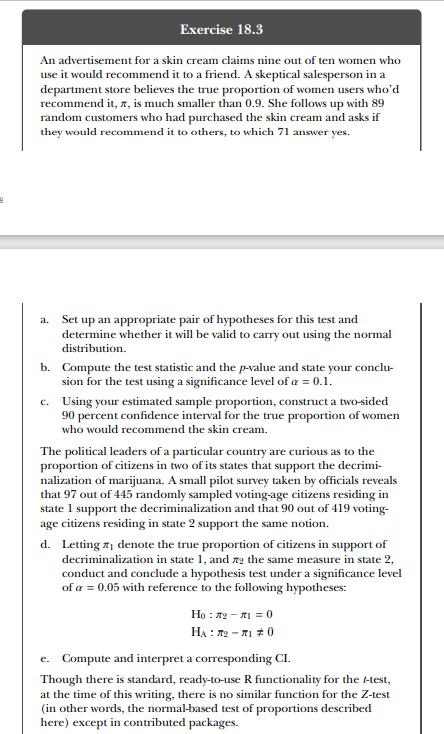

## Raspunsuri

```r
#a.
#Ipoteze: H0: p=0.9 // Ha: p <0.9
#intrucat ambele sunt adevarate, putem accepta sa se efectueze cu o distributie normala

p<-0.9
n<-89
x<-71
p.hat<-x/n
n*p.hat>5&n*(1-p.hat)>5
```

```
## [1] TRUE
```

```r
#b.

#valoarea p este prea mica, exista destule dovezi statistice pentru a respinge H0 in favoarea Ha.
z.test<-(p.hat-p)/(sqrt(p*(1-p)/n))
pnorm(z.test)
```

```
## [1] 0.0006514802
```

```r
#c. CI

#se exclude media pretinsa de 0.9

p.hat+c(-1,1)*qnorm(0.99)*sqrt(p*(1-p)/n)
```

```
## [1] 0.7237751 0.8717305
```

```r
x1<-97
n1<-445
x2<-90
n2<-419

p.hat1<-x1/n1
p.hat2<-x2/n2

#d.
alpha<-0.05
#Ipoteze: H0 : p2-p1 = 0 // Ha: p2-p1 != 0

#valoarea p este una mare. Nu exista suficiente dovezi statistice ca probabilitatea este diferita in fiecare tara -> varianta cumulata

prop.test(c(x2,x1),c(n2,n1),alternative = "two.sided",conf.level = 1-alpha, correct = FALSE)
```

```
##
##  2-sample test for equality of proportions without continuity correction
##
## data:  c(x2, x1) out of c(n2, n1)
## X-squared = 0.012871, df = 1, p-value = 0.9097
## alternative hypothesis: two.sided
## 95 percent confidence interval:
##  -0.05811507  0.05175429
## sample estimates:
##    prop 1    prop 2
## 0.2147971 0.2179775
```

```r
p<-(x1+x2)/(n1+n2)
p
```

```
## [1] 0.2164352
```

```r
#testarea cu calculul manual
z<-(p.hat2-p.hat1)/(sqrt(p*(1-p)*(1/n1+1/n2)))
z
```

```
## [1] -0.1134513
```

```r
pval<-2*pnorm(z)
pval
```

```
## [1] 0.9096728
```

```r
#e. crearea intervalului de incredere statistic + cricital Value*SE

#Intervalul de incredere include valoarea 0, asigurand ca ambele stari ar putea avea aceeasi proportie.

se<-sqrt(p*(1-p)*(1/n1+1/n2))
(p.hat2-p.hat1)+c(-1,1)*qnorm(1-alpha/2)*se
```

```
## [1] -0.05812427  0.05176349
```

## 6. Testarea variabilelor categorice

Testul Z bazat normal este un caz particular al unui set de date care poate avea doua valori. Pentru a testa statistic afirmatiile referitoare la variabile categorice mai generale, cu mai mult de doua niveluri distincte, se foloseste testul chi-patrat. Testul chi-patrat este notat cu χ².

Exista doua variante comune ale testului chi-patrat:

#### 6.1 O singura variabila categorica

La fel ca testul Z, testul chi-patrat unidimensional este, de asemenea, preocupat cu compararea proportiilor, dar intr-un cadru in care exista mai mult de doua proportii. Un test chi-patrat este utilizat atunci cand avem k niveluri (sau categorii) cu o variabila categorica si dorim sa formulam o ipoteza cu privire la frecventele lor relative pentru a afla ce proportie din n observatii se incadreaza in fiecare categorie definita. Trebuie sa se presupuna excluderea reciproca a categoriilor (o observatie nu poate lua mai mult de o categorie posibila), dar si exhaustivitatea categoriilor (cele k categorii acopera orice caz posibil).

Sa presupunem ca un cercetator in sociologie este interesat de dispersia proportiilor de par facial la barbatii din orasul sau si daca acestea sunt reprezentate in mod uniform in populatia masculina. El defineste o variabila categoriala cu trei niveluri: barbierit complet (1), numai barba sau numai mustata (2) si barba si mustata (3). El colecteaza date despre 53 de barbati selectati aleatoriu si constata urmatoarele rezultate:

```r
hairy <- c(2,3,2,3,2,1,3,3,2,2,3,2,2,2,3,3,3,2,3,2,2,2,1,3,2,2,2,1,2,2,3,
2,2,2,2,1,2,1,1,1,2,2,2,3,1,2,1,2,1,2,1,3,3)
```

Fie π1, π2 și π3 proportiile reale de bărbați din oraș care se încadrează în grupurile 1, 2 și, respectiv, 3. Prin urmare, se va cauta sa se testeze urmatoarele ipoteze:

- H0 : π1 = π2 = π3 = 1/3
- HA : H0 is incorrect

În aceste tipuri de probleme, H0 sustine că proporțiile din fiecare grup sunt egale cu valorile declarate, iar HA este că datele, în ansamblul lor, nu corespund proporțiilor definite în H0. Testul se efectuează presupunând că ipoteza nulă este adevărată, iar dovezile împotriva setării de bază, fără schimbări, vor fi reprezentate de o valoare mica a p-value.

##### **Testul Chi-Patrat de distributie**

În acest tip de test chi-pătrat, este important sa retinem urmatoarele:

- Termenul de potrivire se referă la apropierea dintre datele observate și distribuția presupusă în ipoteza H0.
- Extremitatea pozitivă a rezultatului χ2 oferă dovezi împotriva lui H0. Ca atare, valoarea p corespunzătoare este întotdeauna calculată ca o arie a cozii superioare.
- La fel ca în exemplul de față, un test de uniformitate simplifică ipoteza nula prin faptul că are proporții nule echivalente π0 = π0(1) = … = π0(k).
- O ipoteza H0 respinsa nu va spune nimic despre valorile reale ale lui πi. Ea sugerează doar că acestea nu urmează în mod specific H0.

Această distribuție unidirecțională este cea care duce la valorile pdefinite ca zone de coadă superioară; decizii precum zonele cu una sau două cozi nu au nicio relevanță în aceste tipuri de teste chi pătrat. Urmatorul grafic prezintă cum arată de fapt funcțiile de densitate, avand trei curbe particulare definite cu ν = 1, ν = 5 și ν = 10 grade de libertate.

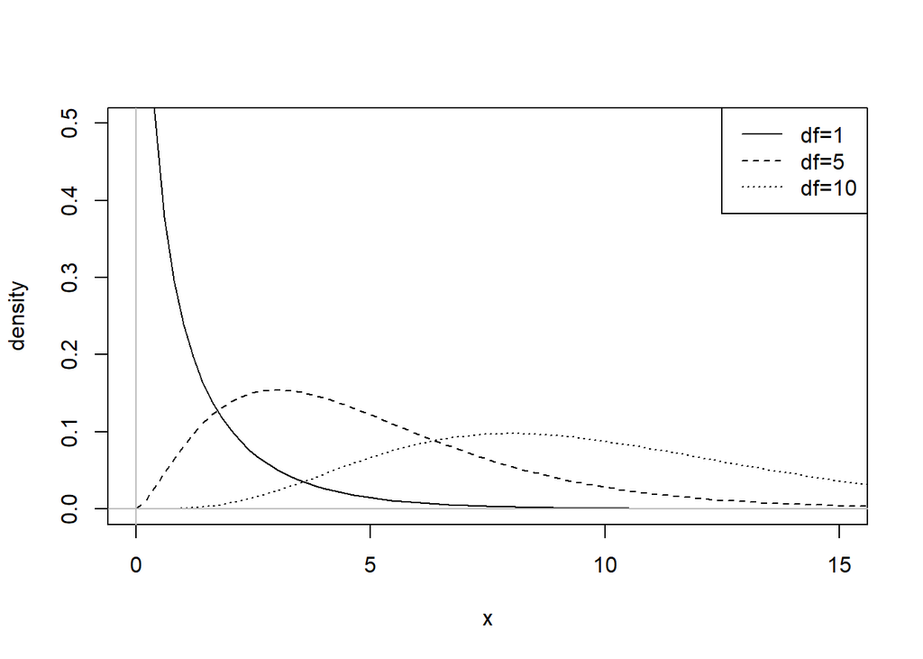

```r
x <- seq(0,20,length=100)
plot(x,dchisq(x,df=1),type="l",xlim=c(0,15),ylim=c(0,0.5),ylab="density")
lines(x,dchisq(x,df=5),lty=2)
lines(x,dchisq(x,df=10),lty=3)
abline(h=0,col="gray")
abline(v=0,col="gray")
legend("topright",legend=c("df=1","df=5","df=10"),lty=1:3)
```

Exemplul cu parul facial este un test de uniformitate a distribuirii frecventelor in 3 categorii. Valorile observate si proportiile lor corespunzatoare se pot regasi in urmatoarea figura:

```r
n <- length(hairy)
n
```

```
## [1] 53
```

```r
hairy.tab <- table(hairy)
hairy.tab
```

```
## hairy
##  1  2  3
## 11 28 14
```

```r
hairy.tab/n
```

```
## hairy
##         1         2         3
## 0.2075472 0.5283019 0.2641509
```

Rezultatele calculelor pentru valorile observate (Oi) si valorile asteptate (Ei) pot fi regasite in urmatoarea matrice:

```r
expected <- 1/3*n
expected
```

```
## [1] 17.66667
```

```r
hairy.matrix <- cbind(1:3,hairy.tab,expected,(hairy.tab-expected)^2/expected)
dimnames(hairy.matrix) <- list(c("clean","beard OR mous.","beard AND mous."),c("i","Oi","Ei","(Oi-Ei)^2/Ei"))
hairy.matrix
```

```
##                 i Oi       Ei (Oi-Ei)^2/Ei
## clean           1 11 17.66667    2.5157233
## beard OR mous.  2 28 17.66667    6.0440252
## beard AND mous. 3 14 17.66667    0.7610063
```

Statistica testului este dată ca fiind suma contribuțiilor din a patra coloană a matricei hairy.matrix:

```r
X2 <- sum(hairy.matrix[,4])
X2
```

```
## [1] 9.320755
```

Valoarea p corespunzătoare este zona cozii superioare corespunzătoare din distribuție chi-pătrat cu ν = 2 grade de libertate:

```r
1-pchisq(X2,df=2)
```

```
## [1] 0.009462891
```

Această valoare p mică sugerează că frecvențele reale în categoriile definite de părul facial nu sunt distribuite în mod uniform (într-un mod egal de 1/3, 1/3, 1/3). Rezultatul testului nu oferă adevăratele proporții, ci doar sugerează că acestea nu le urmează pe cele din H0.

##### **Functia chisq.test**

Funcția chisq.test ia vectorul de frecvențe observate ca prim argument x. Pentru exemplul părului facial, această linie simplă de cod oferă, prin urmare, aceleași rezultate ca cele găsite anterior:

```r
chisq.test(x=hairy.tab)
```

```
##
##  Chi-squared test for given probabilities
##
## data:  hairy.tab
## X-squared = 9.3208, df = 2, p-value = 0.009463
```

În mod implicit, funcția efectuează un test de uniformitate, luând numărul de categorii ca lungime a vectorului furnizat x. Cu toate acestea, să presupunem că cercetătorul care colectează datele privind părul facial își dă seama că datele au fost colectate in Noiembrie, o lună în care multor bărbați le crește mustața în sprijinul miscarii “Mo-vember” pentru a crește importanta aratata sănătății bărbaților. Acest lucru schimbă rezultatele cu privire la frecventele reale în ceea ce privește incadrarea in cele 3 categorii. Cercetatorul dorește acum să testeze următoarele ipoteze:

- H0 : π0(1) = 0,25; π0(2) = 0,5; π0(3) = 0,25
- HA : H0 este incorect.

În cazul în care nu se dorește un test de uniformitate, atunci când ratele “adevărate” în cadrul categoriilor nu sunt toate la fel, funcția chisq.test are nevoie de pasarea ca argument pentru functia p a proporțiilor nule sub forma unui vector de aceeași lungime ca și x. În mod firesc, fiecare intrare din p trebuie să corespundă categoriilor din x:

```r
chisq.test(x=hairy.tab,p=c(0.25,0.5,0.25))
```

```
##
##  Chi-squared test for given probabilities
##
## data:  hairy.tab
## X-squared = 0.50943, df = 2, p-value = 0.7751
```

Obtinem astfel o valoare mare pentru p-value, care ne arata ca nu avem suficiente dovezi pentru a discredita H0, deci nu putem spune ca valorile proportiilor din H0 sunt incorecte.

#### 6.2 Doua variabile categorice

Testul chi-pătrat se poate aplica și în situația în care avem două variabile categorice care se exclud reciproc și sunt exhaustive - le vom nota variabila A și variabila B. Testul acesta este utilizat pentru a detecta dacă ar putea exista unele relații de influență (cu alte cuvinte, dependență) între A și B prin observarea modului în care distribuția frecvențelor se modifică împreună cu categoriile lor. În cazul în care nu există nicio relație, distribuția frecvențelor în variabila A nu va avea nicio legătură cu distribuția frecvențelor în variabila B. Ca atare, această forma particulară a testului chi-pătrat se numește **test de independență** și se realizează întotdeauna cu următoarele ipoteze:

- H0 : Variabilele A și B sunt independente (nu există nicio relație între A și B)
- HA : Variabilele A și B nu sunt independente (există o relație între A și B)

O abatere generală mare de la frecvențele așteptate va avea ca rezultat o valoare mica pentru p-value și, prin urmare, va oferi dovezi împotriva ipotezei H0.

Pentru exemplificare se va folosi urmatorul scenariu. Sa presupunem ca dermatologii unui spital sunt interesati sa afle succesul lor in tratarea afectiunilor de piele. Au fost in total N = 355 pacienti tratati, fiecare primind unul din cele 4 tratamente posibile: pastile, injectii, tratament cu laser sau un remediu bazat pe plante medicinale. Nivelurile de succes in tratarea afectiunilor sunt urmatoarele: succes complet, succes partial sau niciun efect. Vom construi matricea **skin** pentru a observa rezultatele tratamentelor:

```r
skin <- matrix(c(20,32,8,52,9,72,8,32,16,64,30,12),4,3,
dimnames=list(c("Injection","Tablet","Laser","Herbal"),
c("None","Partial","Full")))
skin
```

```
##           None Partial Full
## Injection   20       9   16
## Tablet      32      72   64
## Laser        8       8   30
## Herbal      52      32   12
```

##### **Testul Chi-Patrat de independenta**

Testul se axează pe modul în care frecvențele a N observații între nivelurile kr (variabila *row*) și nivelurile kc (variabila *column*) sunt distribuite. Statistica testului χ² este dată de formula:

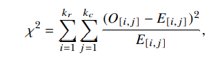

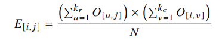

Din nou, valoarea lui p-value este întotdeauna o valoare cu coadă superioară și putem considera testul valid dacă este îndeplinită condiția ca cel puțin 80% din valorile E[i, j] să fie cel puțin 5.

Pentru acest calcul este important sa tinem cont de urmatoarele:

- Nu este necesar sa ne asumam ca kr = kc
- Formula folosita pentru statistica testului chi-patrat cu doua valori categorice functioneaza pe acelasi principiu ca formula pentru testul chi-patrat cu o singura valoare categorica. Mai exact, ambele calculeaza suma patratelor diferentelor dintre valorile observate si cele asteptate.
- O ipoteza H0 respinsa nu ne spune nimic despre natura modului in care frecventele depind una de alta, doar ne sugereaza ca exista o dependenta intre doua variabile categorice

In calculul valorilor Eij (valorile asteptate), vom avea nevoie de calcularea sumelor liniilor si a coloanelor, dar si de numarul de linii si de coloane ale matricei **skin**:

```r
rowSums(skin)
```

```
## Injection    Tablet     Laser    Herbal
##        45       168        46        96
```

```r
colSums(skin)
```

```
##    None Partial    Full
##     112     121     122
```

```r
kr <- nrow(skin)
kc <- ncol(skin)
```

Pentru a continua calculul, trebuie sa inmultim fiecare suma din **rowSums** cu fiecare suma din **colSums**, pentru aceasta vom repeta valorile fiecarui element din vectorul **colSums** de 4 ori pentru ca cei doi vectori sa fie de dimensiuni egale. Urmatorul cod calculeaza matricea rezultatelor asteptate, pas cu pas:

```r
rep(colSums(skin),each=kr)
```

```
##    None    None    None    None Partial Partial Partial Partial    Full    Full
##     112     112     112     112     121     121     121     121     122     122
##    Full    Full
##     122     122
```

```r
rep(colSums(skin),each=kr)*rowSums(skin)
```

```
##    None    None    None    None Partial Partial Partial Partial    Full    Full
##    5040   18816    5152   10752    5445   20328    5566   11616    5490   20496
##    Full    Full
##    5612   11712
```

```r
rep(colSums(skin),each=kr)*rowSums(skin)/sum(skin)
```

```
##     None     None     None     None  Partial  Partial  Partial  Partial
## 14.19718 53.00282 14.51268 30.28732 15.33803 57.26197 15.67887 32.72113
##     Full     Full     Full     Full
## 15.46479 57.73521 15.80845 32.99155
```

```r
skin.expected <- matrix(rep(colSums(skin),each=kr)*rowSums(skin)/sum(skin),nrow=kr,ncol=kc,dimnames=dimnames(skin))
skin.expected
```

```
##               None  Partial     Full
## Injection 14.19718 15.33803 15.46479
## Tablet    53.00282 57.26197 57.73521
## Laser     14.51268 15.67887 15.80845
## Herbal    30.28732 32.72113 32.99155
```

E de precizat faptul ca toate valorile asteptate sunt mai mari decat 5, asa cum este de preferat pentru acest test.

Vom retine apoi intr-un obiect numit **skin.array** matricele de care avem nevoie in calculul lui χ²:

```r
skin.array <- array(data=cbind(skin,skin.expected,
(skin-skin.expected)^2/skin.expected),
dim=c(kr,kc,3),
dimnames=list(dimnames(skin)[[1]],dimnames(skin)[[2]],
c("O[i,j]","E[i,j]",
"(O[i,j]-E[i,j])^2/E[i,j]")))
skin.array
```

```
## , , O[i,j]
##
##           None Partial Full
## Injection   20       9   16
## Tablet      32      72   64
## Laser        8       8   30
## Herbal      52      32   12
##
## , , E[i,j]
##
##               None  Partial     Full
## Injection 14.19718 15.33803 15.46479
## Tablet    53.00282 57.26197 57.73521
## Laser     14.51268 15.67887 15.80845
## Herbal    30.28732 32.72113 32.99155
##
## , , (O[i,j]-E[i,j])^2/E[i,j]
##
##                None   Partial        Full
## Injection  2.371786 2.6190199  0.01852279
## Tablet     8.322545 3.7932587  0.67978582
## Laser      2.922614 3.7607992 12.74002590
## Herbal    15.565598 0.0158926 13.35630339
```

Apoi vom calcula χ² ca fiind suma elementelor din **skin.array**:

```r
X2 <- sum(skin.array[,,3])
X2
```

```
## [1] 66.16615
```

Valoarea p-value corespunzatoare pentru testul de independenta este:

```r
1-pchisq(X2,df=(kr-1)*(kc-1))
```

```
## [1] 2.492451e-12
```

Aceasta valoare p-value este extrem de mica, ceea ce ne ofera dovezi clare pentru respingerea ipotezei H0. In concluzie, este acceptata ipoteza Ha si putem afirma faptul ca exista o relatie intre tipurile de tratament pentru afectiunile de piele si gradul de succes in vindecarea afectiunilor.

##### **Functia chisq.test**

Functia **chisq.test** efectueaza un test chi-patrat de independenta, tinand cont de frecventele liniilor si coloanelor, asa cum se realizeaza manual pentru exemplul cu afectiunile de piele. Urmatorul rezultat confirma calculele efectuate anterior:

```r
chisq.test(x=skin)
```

```
##
##  Pearson's Chi-squared test
##
## data:  skin
## X-squared = 66.166, df = 6, p-value = 2.492e-12
```